# Investigate Dataset: TMDB Movie Dataset

- Introduction
- Data Wrangling
- Exploratory Data Analysis
- Conclusions

## Introduction

> This data set contains information about 10,000 movies collected from The Movie Database (TMDb), including user ratings and revenue.

> Certain columns, like ‘cast’ and ‘genres’, contain multiple values separated by pipe (|) characters.

> There are some odd characters in the ‘cast’ column. Don’t worry about cleaning them. You can leave them as is.

> The final two columns ending with “_adj” show the budget and revenue of the associated movie in terms of 2010 dollars, accounting for inflation over time.

### Questions to address.

> Which genres lead in each category the during the last 5 years?

> What kinds of properties are associated with movies that have high revenues(adj)?

> What is the main insight of the top 10 biggest box office bombs?

> What is the main insight of the top 10 box office successes?

```python
import numpy as np
import pandas as pd
import matplotlib.pyplot as plt
import seaborn as sns
% matplotlib inline
```

## Data Wrangling

### General Properties

```python
# Load your data and print out a few lines. Perform operations to inspect data
# types and look for instances of missing or possibly errant data.
df = pd.read_csv('tmdb_movies.csv')
df.head(1)
```

|  | id | imdb_id | popularity | budget | revenue | original_title | cast | homepage | director | tagline | ... | overview | runtime | genres | production_companies | release_date | vote_count | vote_average | release_year | budget_adj | revenue_adj |
| --- | --- | --- | --- | --- | --- | --- | --- | --- | --- | --- | --- | --- | --- | --- | --- | --- | --- | --- | --- | --- | --- |
| 0 | 135397 | tt0369610 | 32.985763 | 150000000 | 1513528810 | Jurassic World | Chris Pratt\|Bryce Dallas Howard\|Irrfan Khan\|Vi... | http://www.jurassicworld.com/ | Colin Trevorrow | The park is open. | ... | Twenty-two years after the events of Jurassic ... | 124 | Action\|Adventure\|Science Fiction\|Thriller | Universal Studios\|Amblin Entertainment\|Legenda... | 6/9/15 | 5562 | 6.5 | 2015 | 1.379999e+08 | 1.392446e+09 |

1 rows × 21 columns

```python
# Dataset shape
df.shape
```

```
(10866, 21)
```

Dataset has 10866 rows and 21 columns

```python
# Check for missing values, datatypes, etc.
df.info()
```

```
<class 'pandas.core.frame.DataFrame'>
RangeIndex: 10866 entries, 0 to 10865
Data columns (total 21 columns):
id                      10866 non-null int64
imdb_id                 10856 non-null object
popularity              10866 non-null float64
budget                  10866 non-null int64
revenue                 10866 non-null int64
original_title          10866 non-null object
cast                    10790 non-null object
homepage                2936 non-null object
director                10822 non-null object
tagline                 8042 non-null object
keywords                9373 non-null object
overview                10862 non-null object
runtime                 10866 non-null int64
genres                  10843 non-null object
production_companies    9836 non-null object
release_date            10866 non-null object
vote_count              10866 non-null int64
vote_average            10866 non-null float64
release_year            10866 non-null int64
budget_adj              10866 non-null float64
revenue_adj             10866 non-null float64
dtypes: float64(4), int64(6), object(11)
memory usage: 1.7+ MB
```

### Data Cleaning

#### 1) Columns to drop:

Imdb_id (don’t need it), Homepage (don’t need it), Tagline (don’t need it), Keywords (don’t need it), Overview (don’t need it), Popularity (couldn’t find info on source and description), Vote_count (couldn’t find info on source and description), Vote_average (couldn’t find info on source and description), release_year (redundant info).

#### 2) Datatype inspection:

Convert release_date to datetime. budget and revenue to FLOAT.

#### 3) Address Null values after dropping columns and datatype conversions

```python
# Drop columns
df.drop(['imdb_id','id','popularity','homepage','tagline','keywords','overview','vote_count','vote_average','release_year'], axis=1, inplace=True)
```

```python
# inspect new dataset
df.head()
```

|  | budget | revenue | original_title | cast | director | runtime | genres | production_companies | release_date | budget_adj | revenue_adj |
| --- | --- | --- | --- | --- | --- | --- | --- | --- | --- | --- | --- |
| 0 | 150000000 | 1513528810 | Jurassic World | Chris Pratt\|Bryce Dallas Howard\|Irrfan Khan\|Vi... | Colin Trevorrow | 124 | Action\|Adventure\|Science Fiction\|Thriller | Universal Studios\|Amblin Entertainment\|Legenda... | 6/9/15 | 1.379999e+08 | 1.392446e+09 |
| 1 | 150000000 | 378436354 | Mad Max: Fury Road | Tom Hardy\|Charlize Theron\|Hugh Keays-Byrne\|Nic... | George Miller | 120 | Action\|Adventure\|Science Fiction\|Thriller | Village Roadshow Pictures\|Kennedy Miller Produ... | 5/13/15 | 1.379999e+08 | 3.481613e+08 |
| 2 | 110000000 | 295238201 | Insurgent | Shailene Woodley\|Theo James\|Kate Winslet\|Ansel... | Robert Schwentke | 119 | Adventure\|Science Fiction\|Thriller | Summit Entertainment\|Mandeville Films\|Red Wago... | 3/18/15 | 1.012000e+08 | 2.716190e+08 |
| 3 | 200000000 | 2068178225 | Star Wars: The Force Awakens | Harrison Ford\|Mark Hamill\|Carrie Fisher\|Adam D... | J.J. Abrams | 136 | Action\|Adventure\|Science Fiction\|Fantasy | Lucasfilm\|Truenorth Productions\|Bad Robot | 12/15/15 | 1.839999e+08 | 1.902723e+09 |
| 4 | 190000000 | 1506249360 | Furious 7 | Vin Diesel\|Paul Walker\|Jason Statham\|Michelle ... | James Wan | 137 | Action\|Crime\|Thriller | Universal Pictures\|Original Film\|Media Rights ... | 4/1/15 | 1.747999e+08 | 1.385749e+09 |

```python
# check for null values
df.isnull().sum()
```

```
budget                     0
revenue                    0
original_title             0
cast                      76
director                  44
runtime                    0
genres                    23
production_companies    1030
release_date               0
budget_adj                 0
revenue_adj                0
dtype: int64
```

```python
# drop rows with null values
df.dropna(inplace=True)
```

```python
# confirm null value drop
df.info()
```

```
<class 'pandas.core.frame.DataFrame'>
Int64Index: 9773 entries, 0 to 10865
Data columns (total 11 columns):
budget                  9773 non-null int64
revenue                 9773 non-null int64
original_title          9773 non-null object
cast                    9773 non-null object
director                9773 non-null object
runtime                 9773 non-null int64
genres                  9773 non-null object
production_companies    9773 non-null object
release_date            9773 non-null object
budget_adj              9773 non-null float64
revenue_adj             9773 non-null float64
dtypes: float64(2), int64(3), object(6)
memory usage: 916.2+ KB
```

```python
# check for rows with budgets that equal 0. Data source advises to treat them as missing values...
df.query('budget == "0"').count()
```

```
budget                  4751
revenue                 4751
original_title          4751
cast                    4751
director                4751
runtime                 4751
genres                  4751
production_companies    4751
release_date            4751
budget_adj              4751
revenue_adj             4751
dtype: int64
```

```python
# check for rows with revenue that equal 0. Data source advises to treat them as missing values...
df.query('revenue == "0"').count()
```

```
budget                  5022
revenue                 5022
original_title          5022
cast                    5022
director                5022
runtime                 5022
genres                  5022
production_companies    5022
release_date            5022
budget_adj              5022
revenue_adj             5022
dtype: int64
```

```python
# check for duplicates
sum(df.duplicated())
```

```
1
```

```python
# drop rows with budget == 0.
df = df.drop(df[df.budget == 0].index)
# drop rows with revenue == 0.
df = df.drop(df[df.revenue == 0].index)
# drop duplicates
df.drop_duplicates(inplace=True)
```

```python
# check
df.info()
```

```
<class 'pandas.core.frame.DataFrame'>
Int64Index: 3805 entries, 0 to 10848
Data columns (total 11 columns):
budget                  3805 non-null int64
revenue                 3805 non-null int64
original_title          3805 non-null object
cast                    3805 non-null object
director                3805 non-null object
runtime                 3805 non-null int64
genres                  3805 non-null object
production_companies    3805 non-null object
release_date            3805 non-null object
budget_adj              3805 non-null float64
revenue_adj             3805 non-null float64
dtypes: float64(2), int64(3), object(6)
memory usage: 356.7+ KB
```

```python
# Address datatype conversions
# convert release_date to datatime
df['release_date'] = pd.to_datetime(df['release_date'])
# split datetime to year, month, day
df['year'], df['month'], df['day'] = df['release_date'].dt.year, df['release_date'].dt.month, df['release_date'].dt.day
df.drop(['release_date'], axis=1, inplace=True)
df['year'].replace([2060,2061,2062,2063,2064,2065,2066,2067,2068],[1960,1961,1962,1963,1964,1965,1966,1967,1968],inplace=True)

# convert both budget and revenue to float
df['budget'] = df['budget'].astype(float)
df['revenue'] = df['revenue'].astype(float)
```

```python
# inspect dataframe
df.head(1)
```

|  | budget | revenue | original_title | cast | director | runtime | genres | production_companies | budget_adj | revenue_adj | year | month | day |
| --- | --- | --- | --- | --- | --- | --- | --- | --- | --- | --- | --- | --- | --- |
| 0 | 150000000.0 | 1.513529e+09 | Jurassic World | Chris Pratt\|Bryce Dallas Howard\|Irrfan Khan\|Vi... | Colin Trevorrow | 124 | Action\|Adventure\|Science Fiction\|Thriller | Universal Studios\|Amblin Entertainment\|Legenda... | 1.379999e+08 | 1.392446e+09 | 2015 | 6 | 9 |

```python
# inspect
df.info()
```

```
<class 'pandas.core.frame.DataFrame'>
Int64Index: 3805 entries, 0 to 10848
Data columns (total 13 columns):
budget                  3805 non-null float64
revenue                 3805 non-null float64
original_title          3805 non-null object
cast                    3805 non-null object
director                3805 non-null object
runtime                 3805 non-null int64
genres                  3805 non-null object
production_companies    3805 non-null object
budget_adj              3805 non-null float64
revenue_adj             3805 non-null float64
year                    3805 non-null int64
month                   3805 non-null int64
day                     3805 non-null int64
dtypes: float64(4), int64(4), object(5)
memory usage: 416.2+ KB
```

#### Let's create classification columns for budget and revenue

```python
# inspect percentiles
df.describe()
```

|  | budget | revenue | runtime | budget_adj | revenue_adj | year | month | day |
| --- | --- | --- | --- | --- | --- | --- | --- | --- |
| count | 3.805000e+03 | 3.805000e+03 | 3805.000000 | 3.805000e+03 | 3.805000e+03 | 3805.000000 | 3805.000000 | 3805.000000 |
| mean | 3.760800e+07 | 1.089734e+08 | 109.351117 | 4.471977e+07 | 1.387159e+08 | 2001.229172 | 7.051774 | 15.344021 |
| std | 4.232179e+07 | 1.772976e+08 | 19.845678 | 4.488697e+07 | 2.169973e+08 | 11.329616 | 3.359889 | 8.438038 |
| min | 1.000000e+00 | 2.000000e+00 | 15.000000 | 9.693980e-01 | 2.370705e+00 | 1960.000000 | 1.000000 | 1.000000 |
| 25% | 1.000000e+07 | 1.433379e+07 | 96.000000 | 1.354637e+07 | 1.925371e+07 | 1995.000000 | 4.000000 | 8.000000 |
| 50% | 2.500000e+07 | 4.621664e+07 | 106.000000 | 3.038360e+07 | 6.284688e+07 | 2004.000000 | 7.000000 | 15.000000 |
| 75% | 5.000000e+07 | 1.260695e+08 | 119.000000 | 6.084153e+07 | 1.658054e+08 | 2010.000000 | 10.000000 | 22.000000 |
| max | 4.250000e+08 | 2.781506e+09 | 338.000000 | 4.250000e+08 | 2.827124e+09 | 2015.000000 | 12.000000 | 31.000000 |

```python
# Bin edges that will be used to "cut" the data into groups
bin_edges_bud = [0,1.354637e+07,3.038360e+07,6.084153e+07,4.250000e+08]
bin_edges_rev = [0,1.925371e+07,6.284688e+07,1.658054e+08,2.827124e+09]
# Labels for the four level groups
bin_names = ['Low','Medium','High','Very_High']
```

```python
# Creates budget and revenue level column
df['budget_level'] = pd.cut(df['budget_adj'], bin_edges_bud, labels=bin_names)
df['revenue_level'] = pd.cut(df['revenue_adj'], bin_edges_rev, labels=bin_names)
```

#### Define a new function that splits rows

To split rows with multiple cast, genre, and production companies. Create new dataframes for cast, genre, and production companies.

```python
# Define split function
def splitDataFrameList(df,target_column,separator):
    ''' df = dataframe to split,
    target_column = the column containing the values to split
    separator = the symbol used to perform the split
    returns: a dataframe with each entry for the target column separated, with each element moved into a new row.
    The values in the other columns are duplicated across the newly divided rows.
    '''
    def splitListToRows(row,row_accumulator,target_column,separator):
        split_row = row[target_column].split(separator)
        for s in split_row:
            new_row = row.to_dict()
            new_row[target_column] = s
            row_accumulator.append(new_row)
    new_rows = []
    df.apply(splitListToRows,axis=1,args = (new_rows,target_column,separator))
    new_df = pd.DataFrame(new_rows)
    return new_df
```

#### Split Data rows

```python
# cast split
df_cast = splitDataFrameList(df,'cast','|')
```

```python
# genres split
df_genre = splitDataFrameList(df,'genres','|')
```

```python
# production companies split
df_prod = splitDataFrameList(df,'production_companies','|')
```

```python
# director split
df_dir = splitDataFrameList(df,'director','|')
```

#### Cleaning outcome

We dropped columns we didn't need. Removed rows with null values. Removed rows with budgets that equal 0, as advised by the data source. Normalized datatypes. Classified budget and revenue columns. Created new dataframes for cast, genre, and production companies.

## Exploratory Data Analysis

### Summary Statistics

###### Reasoning

> Lets look at the data statistics to get a sense of the data in terms of the spread, mean, std etc.

```python
# inspect statistics
df.describe()
```

|  | budget | revenue | runtime | budget_adj | revenue_adj | year | month | day |
| --- | --- | --- | --- | --- | --- | --- | --- | --- |
| count | 3.805000e+03 | 3.805000e+03 | 3805.000000 | 3.805000e+03 | 3.805000e+03 | 3805.000000 | 3805.000000 | 3805.000000 |
| mean | 3.760800e+07 | 1.089734e+08 | 109.351117 | 4.471977e+07 | 1.387159e+08 | 2001.229172 | 7.051774 | 15.344021 |
| std | 4.232179e+07 | 1.772976e+08 | 19.845678 | 4.488697e+07 | 2.169973e+08 | 11.329616 | 3.359889 | 8.438038 |
| min | 1.000000e+00 | 2.000000e+00 | 15.000000 | 9.693980e-01 | 2.370705e+00 | 1960.000000 | 1.000000 | 1.000000 |
| 25% | 1.000000e+07 | 1.433379e+07 | 96.000000 | 1.354637e+07 | 1.925371e+07 | 1995.000000 | 4.000000 | 8.000000 |
| 50% | 2.500000e+07 | 4.621664e+07 | 106.000000 | 3.038360e+07 | 6.284688e+07 | 2004.000000 | 7.000000 | 15.000000 |
| 75% | 5.000000e+07 | 1.260695e+08 | 119.000000 | 6.084153e+07 | 1.658054e+08 | 2010.000000 | 10.000000 | 22.000000 |
| max | 4.250000e+08 | 2.781506e+09 | 338.000000 | 4.250000e+08 | 2.827124e+09 | 2015.000000 | 12.000000 | 31.000000 |

> Highest budget allotted to a film was approx 425 million!

> Highest revenue from a film was approx and 2.781 billion!

> Movie release years range from 1960 to 2015, with most between 1995 and 2015.

### Distribution Summary

###### Reasoning

> Lets look at the data distribution to a sense of the "majority"

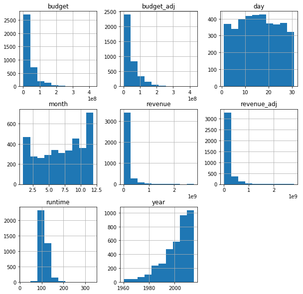

```python
# inspect distribution of variables
df.hist(figsize=(10,10));
```

#### The majority of movies have:

> a budget between 0-70 million.

> revenues between 0-250 million.

> recently released, between 1995-2015. during the holiday season.

> have runtime between 80-150 minutes.

### Count of Movies Produced Over Time

###### Reasoning

> Let's get picture of how many movies are being produced over time to compare it with other metrics such as revenue and budget

```python
# copy dataframe
# drop columns that are not needed
dfc = df.copy()
dfc.drop(['budget','budget_level','cast','director','original_title','production_companies','revenue','revenue_adj','revenue_level','runtime','genres','day','month'], axis=1, inplace=True)
```

```python
# groupby year and count
dfc = dfc.groupby('year').count()
```

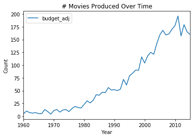

```python
# plot timeseries of movies produced over time
dfc.plot()
plt.xlabel('Year')
plt.ylabel('Count')
plt.title('# Movies Produced Over Time')
plt.legend()
plt.show()
```

> Movie production has increased over the years but seems to have reached a plateau over the last 5 years.

### Sum and Mean of Adjusted Budget.

###### Reasoning

> Let's get picture of how the cumulative sum of all movie budgets is changing over time to compare it with mean budget over time.

##### Sum Adjusted Budget Time Series

```python
# copy dataframe
# drop columns that are not needed
df2 = df.copy()
df2.drop(['budget','budget_level','cast','director','original_title','production_companies','revenue','revenue_adj','revenue_level','runtime','genres','day','month'], axis=1, inplace=True)
```

```python
# groupy year and sum
df2 = df2.groupby('year').sum()
```

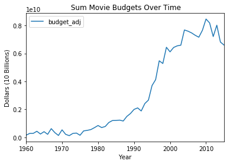

```python
# plot timeseries of movies budgets over time
df2.plot()
plt.xlabel('Year')
plt.ylabel('Dollars (10 Billions)')
plt.title(' Sum Movie Budgets Over Time')
plt.legend()
plt.show()
```

> The cumulative sum of movie budgets has increased over the years but seems to have reached a plateau over the last 5 years. Makes sense since movie production has also increased.

#### Mean Adjusted Budget Time Series

```python
# copy dataframe
# drop columns that are not needed
df2m = df.copy()
df2m.drop(['budget','budget_level','cast','director','original_title','production_companies','revenue','revenue_adj','revenue_level','runtime','genres','day','month'], axis=1, inplace=True)
```

```python
# groupy year and mean
df2m = df2m.groupby('year').mean()
```

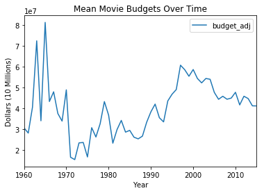

```python
# plot timeseries of mean movies budgets over time
df2m.plot()
plt.xlabel('Year')
plt.ylabel('Dollars (10 Millions)')
plt.title('Mean Movie Budgets Over Time')
plt.legend()
plt.show()
```

> The mean of movie budgets has fluctuated over time. Movies today seem to be cheaper to make compared to those in the 1960's. The mean budget for movies today seems to have settled at around 40 - 45 million dollars.

> > The sum of movie budget has increased because of the increase of movie production and not because movie are more expensive to make.

### Sum and Mean of Adjusted Revenue.

###### Reasoning

> Let's get picture of how the cumulative sum of all movie revenues is changing over time to compare it with the mean over time.

##### Sum Adjusted Revenue Time Series

```python
# copy dataframe
# drop columns that are not needed
df1 = df.copy()
df1.drop(['budget','budget_adj','budget_level','cast','director','original_title','production_companies','revenue','revenue_level','runtime','genres','day','month'], axis=1, inplace=True)
```

```python
# groupy year and sum
df1 = df1.groupby('year').sum()
```

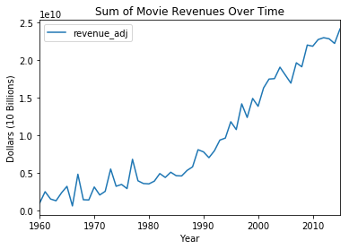

```python
# plot timeseries of movies revenues over time
df1.plot()
plt.xlabel('Year')
plt.ylabel('Dollars (10 Billions)')
plt.title('Sum of Movie Revenues Over Time')
plt.legend()
plt.show()
```

> The cumulative sum of movie revenue has increased over the years.

#### Mean Adjusted Revenue Time Series

```python
# copy dataframe
# drop columns that are not needed
df1m = df.copy()
df1m.drop(['budget','budget_adj','budget_level','cast','director','original_title','production_companies','revenue','revenue_level','runtime','genres','day','month'], axis=1, inplace=True)
```

```python
# groupy year and mean
df1m = df1m.groupby('year').mean()
```

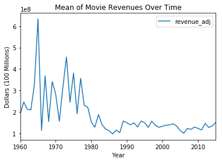

```python
# plot timeseries of mean movies revenues over time
df1m.plot()
plt.xlabel('Year')
plt.ylabel('Dollars (100 Millions)')
plt.title('Mean of Movie Revenues Over Time')
plt.legend()
plt.show()
```

> Adjusted for inflation, movies raked in more money between the 1960's and 1980's vs today! Interesting...

> > The sum of movie reveues has increased because of the increase of movie production and not because movie are raking in more money.

### Which genre has lead in each category in the last 5 years?

###### Reasoning

> Lets look at which genre lead in each category by year.

> > Important to determine which genre is most successful so we can use in conculsion.

```python
# copy dataframe and groupby genres and year and aggregate by sum
df_genre_lead = df_genre.copy().groupby(['genres','year']).sum()
# drop columns not needed
df_genre_lead.drop(['runtime','day','month'], axis=1, inplace=True)
```

```python
# select genres with highest revenue per year
print(df_genre_lead.query('year == 2010').idxmax())
print(df_genre_lead.query('year == 2011').idxmax())
print(df_genre_lead.query('year == 2012').idxmax())
print(df_genre_lead.query('year == 2013').idxmax())
print(df_genre_lead.query('year == 2014').idxmax())
print(df_genre_lead.query('year == 2015').idxmax())
```

```
budget            (Action, 2010)
budget_adj        (Action, 2010)
revenue        (Adventure, 2010)
revenue_adj    (Adventure, 2010)
dtype: object
budget            (Action, 2011)
budget_adj        (Action, 2011)
revenue        (Adventure, 2011)
revenue_adj    (Adventure, 2011)
dtype: object
budget            (Action, 2012)
budget_adj        (Action, 2012)
revenue        (Adventure, 2012)
revenue_adj    (Adventure, 2012)
dtype: object
budget            (Action, 2013)
budget_adj        (Action, 2013)
revenue        (Adventure, 2013)
revenue_adj    (Adventure, 2013)
dtype: object
budget         (Action, 2014)
budget_adj     (Action, 2014)
revenue        (Action, 2014)
revenue_adj    (Action, 2014)
dtype: object
budget         (Adventure, 2015)
budget_adj     (Adventure, 2015)
revenue        (Adventure, 2015)
revenue_adj    (Adventure, 2015)
dtype: object
```

> In 4 of the last 5 years Action movies have been the most expensive to produce. Adventure movies over took Action in 2015. Adventure movies has commanded most of the revenues in 4 of the last 5 years with 2014 being the year it fell behind but it quickly bounced back on 2015.

### What kinds of properties are associated with movies that have high revenues(adj)?

#### Reasoning

> Let's look at the Top performers by revenues_adj so we can pick out the best producers and use for the Conclusion

#### Top 100 Cast

```python
# copy dataframe and groupby cast and aggregate by sum
# drop columns not needed
df_cast_rev = df_cast.copy().groupby('cast',as_index=False).sum()
df_cast_rev.drop(['budget','budget_adj','runtime','revenue','month','day','year'], axis=1, inplace=True)
```

```python
# sort values
df_cast_rev = df_cast_rev.sort_values('revenue_adj', ascending=False).head(100)
```

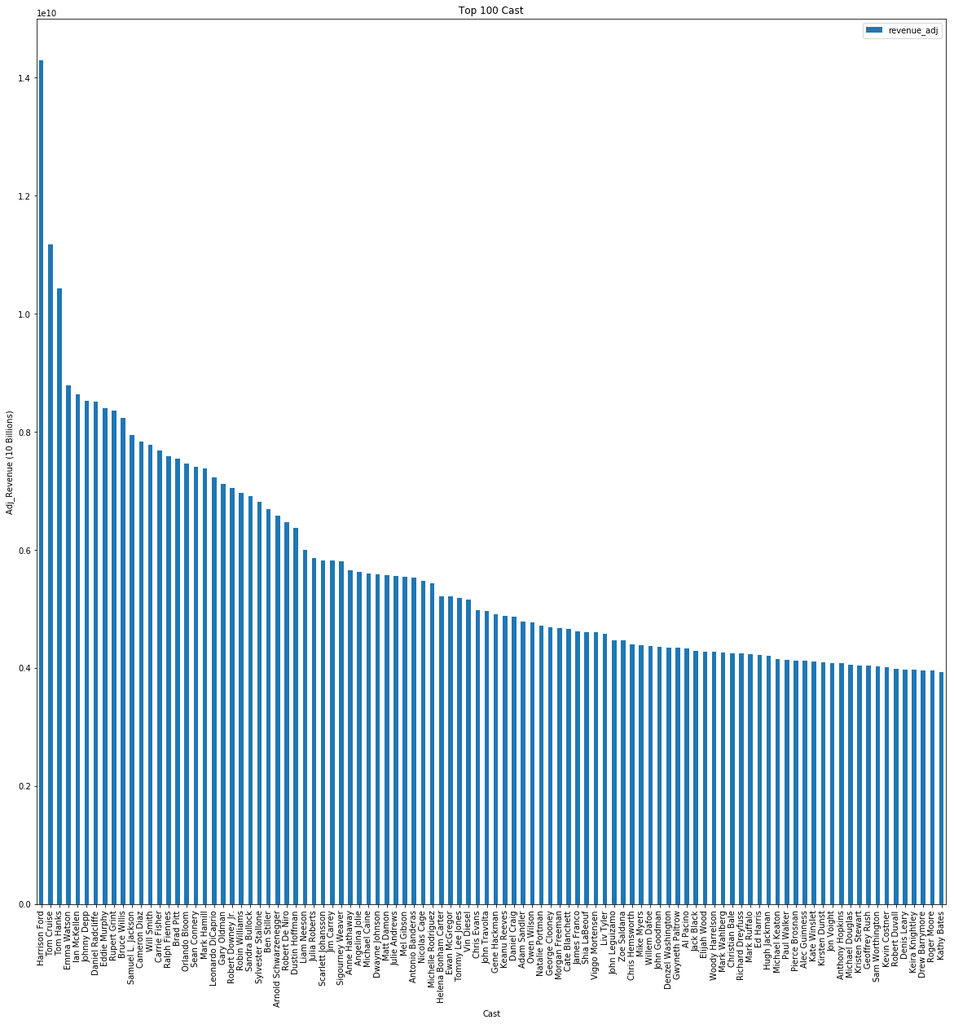

```python
# plot bar graph of top cast
df_cast_rev.plot.bar(x='cast', y='revenue_adj',figsize=(20,20))
plt.xlabel('Cast')
plt.ylabel('Adj_Revenue (10 Billions)')
plt.title('Top 100 Cast')
plt.legend()
plt.show()
```

> Harrison Ford leads with rake in revenue of 14 Billion Dollars! Tom Cruise and Tom Hanks follow with 11 Billion and 10.5 Billion respectfully.

###### Top Genres

```python
# copy dataframe and groupby genre and aggregate by sum
# drop columns not needed
df_genre_rev = df_genre.copy().groupby('genres',as_index=False).sum()
df_genre_rev.drop(['budget','budget_adj','runtime','revenue','month','day','year'], axis=1, inplace=True)
```

```python
# sort values
df_genre_rev = df_genre_rev.sort_values('revenue_adj', ascending=False)
```

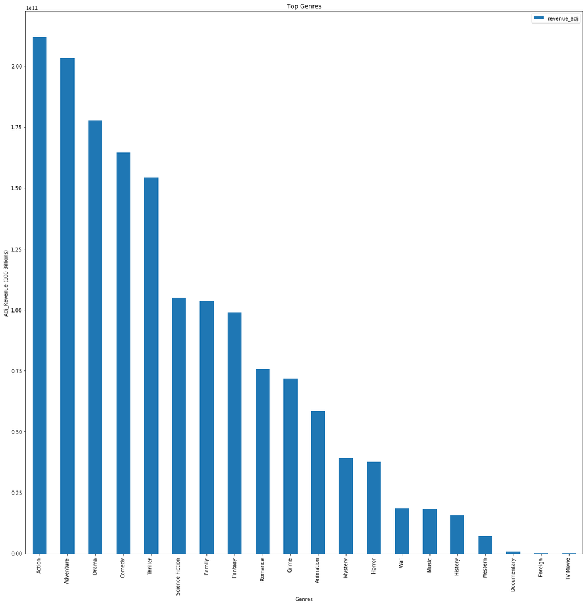

```python
# plot bar graph of top genres
df_genre_rev.plot.bar(x='genres', y='revenue_adj',figsize=(20,20))
plt.xlabel('Genres')
plt.ylabel('Adj_Revenue (100 Billions)')
plt.title('Top Genres')
plt.legend()
plt.show()
```

> Action, Adventure, Drama, Comedy, and Thriller lead with 210, 200, 175, 160, 150 Billion Dollars respectfully.

##### Top Production Companies

```python
# copy dataframe and groupby production companies and aggregate by sum
# drop columns not needed
df_prod_rev = df_prod.groupby('production_companies',as_index=False).sum()
df_prod_rev.drop(['budget','budget_adj','runtime','revenue','month','day','year'], axis=1, inplace=True)
```

```python
# sort values
df_prod_rev = df_prod_rev.sort_values('revenue_adj', ascending=False).head(100)
```

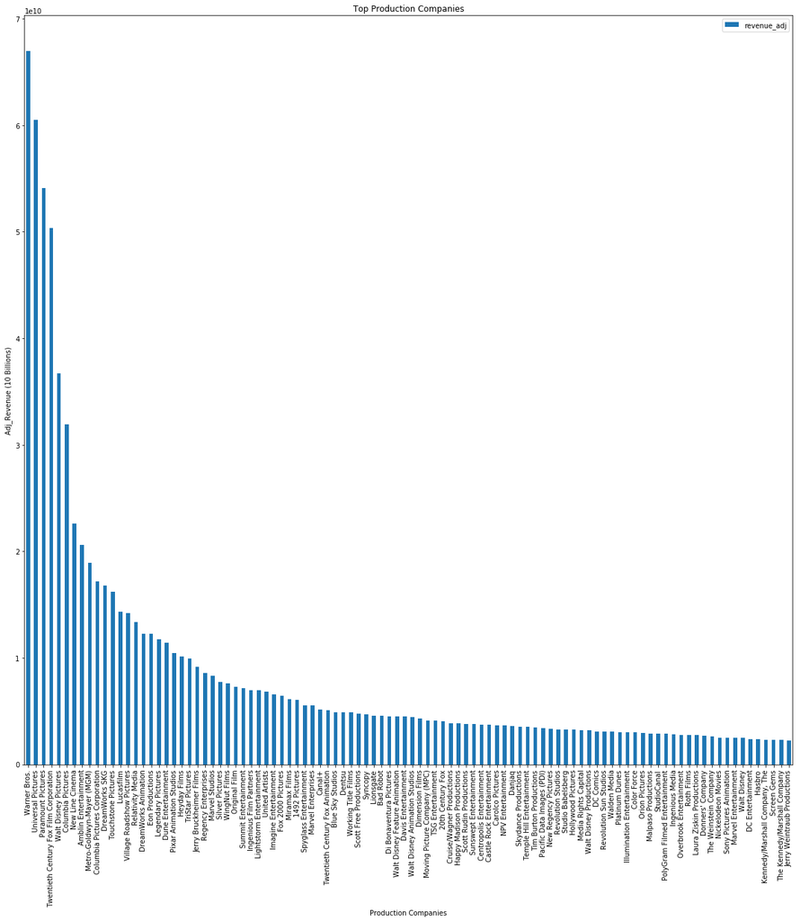

```python
# plot bar graph of top production companies
df_prod_rev.plot.bar(x='production_companies', y='revenue_adj',figsize=(20,20))
plt.xlabel('Production Companies')
plt.ylabel('Adj_Revenue (10 Billions)')
plt.title('Top Production Companies')
plt.legend()
plt.show()
```

> Warner Bros., Universal Pictures, Paramount Pictures, Twentieth Century, and Walt Disney lead with 67, 61, 54, 50, 37 Billion respectfully.

##### Top Directors

```python
# copy dataframe and groupby director and aggregate by sum
# drop columns not needed
df_dir_rev = df_dir.groupby('director',as_index=False).sum()
df_dir_rev.drop(['budget','budget_adj','runtime','revenue','month','day','year'], axis=1, inplace=True)
```

```python
# sort values
df_dir_rev = df_dir_rev.sort_values('revenue_adj', ascending=False).head(100)
```

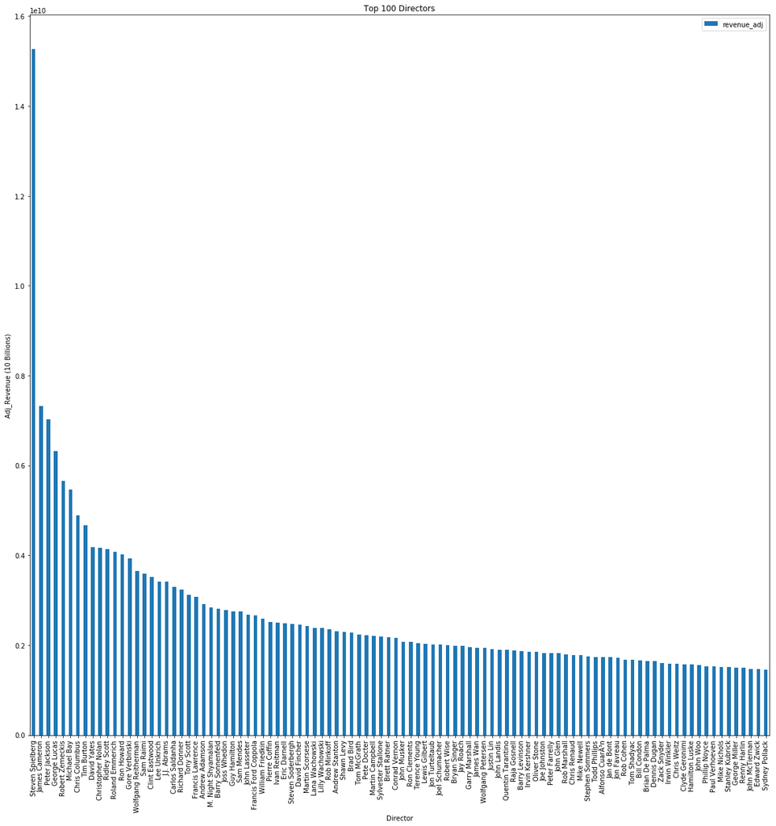

```python
# plot bar graph of top directors
df_dir_rev.plot.bar(x='director', y='revenue_adj',figsize=(20,20))
plt.xlabel('Director')
plt.ylabel('Adj_Revenue (10 Billions)')
plt.title('Top 100 Directors')
plt.legend()
plt.show()
```

> Steven Spielberg leads with 15 Billion in revenues! James Cameron, Peter Jackson, and George Lucas follow with 7.2, 7.0, 6.2 Billion. Steven has more than double the runner up!

##### Reasoning

> Is there a connection between revenue and budget? Let's see what the data says...

```python
# copy dataframe and groupby revenue_level and budget_level and aggregate by count
# drop columns not needed
df_rev_bud = df.copy().groupby(['revenue_level','budget_level'],as_index=False).count()
df_rev_bud.drop(['budget','revenue','cast','director','runtime','genres','production_companies','budget_adj','revenue_adj','year','month','day'], axis=1, inplace=True)
# print results
print(df_rev_bud)
print(df_rev_bud.groupby('budget_level').sum())
print(df_rev_bud.groupby('revenue_level').sum())
```

```
   revenue_level budget_level  original_title
0            Low          Low             559
1            Low       Medium             248
2            Low         High             109
3            Low    Very_High              35
4         Medium          Low             242
5         Medium       Medium             343
6         Medium         High             272
7         Medium    Very_High              95
8           High          Low             101
9           High       Medium             268
10          High         High             356
11          High    Very_High             225
12     Very_High          Low              52
13     Very_High       Medium              90
14     Very_High         High             214
15     Very_High    Very_High             596
              original_title
budget_level
Low                      954
Medium                   949
High                     951
Very_High                951
               original_title
revenue_level
Low                       951
Medium                    952
High                      950
Very_High                 952
```

> 62.67% of movies with Very_High budgets have Very_High revenues. 62.6% of movies with Very_revenue budget have Very_High budgets.

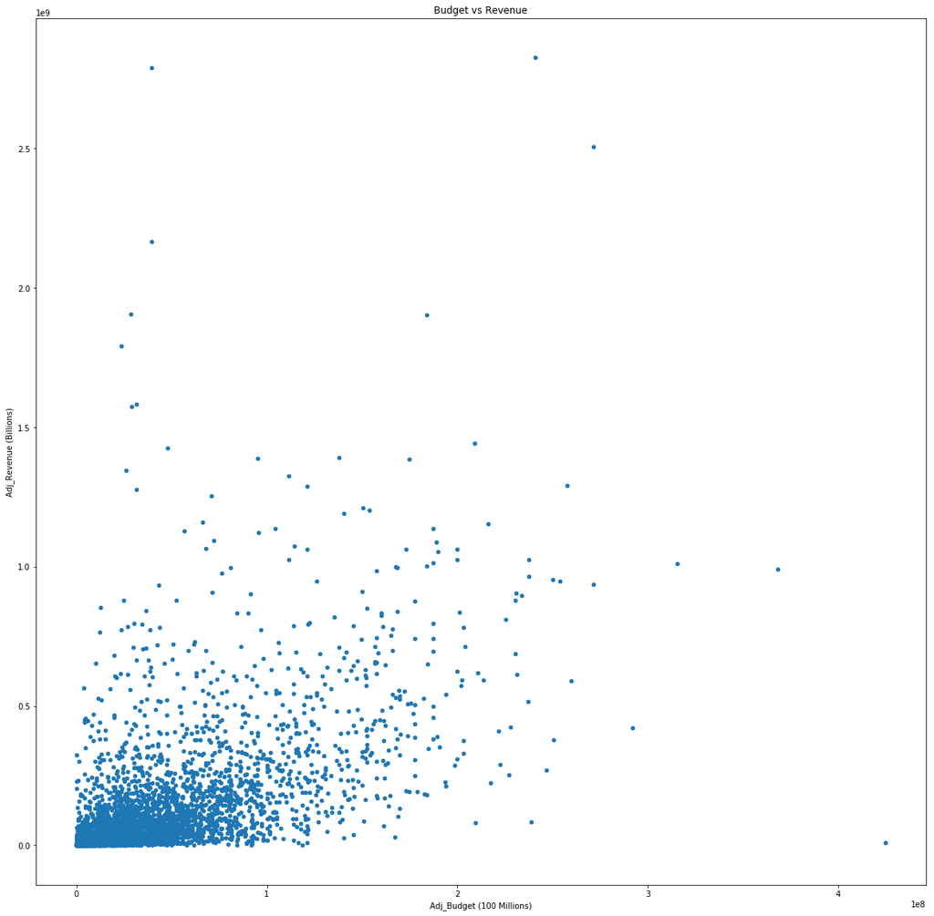

```python
# plot scatter plot of budget vs revenue
df.plot(x='budget_adj', y='revenue_adj',figsize=(20,20),kind='scatter')
plt.xlabel('Adj_Budget (100 Millions)')
plt.ylabel('Adj_Revenue (Billions)')
plt.title('Budget vs Revenue')
plt.legend()
plt.show()
```

> Does not seem to be a correlation between revenue and budget, there might be a very small positive correlation if any.

##### Reasoning

> Is there a connection between revenue and runtime? Again, let's see what the data says...

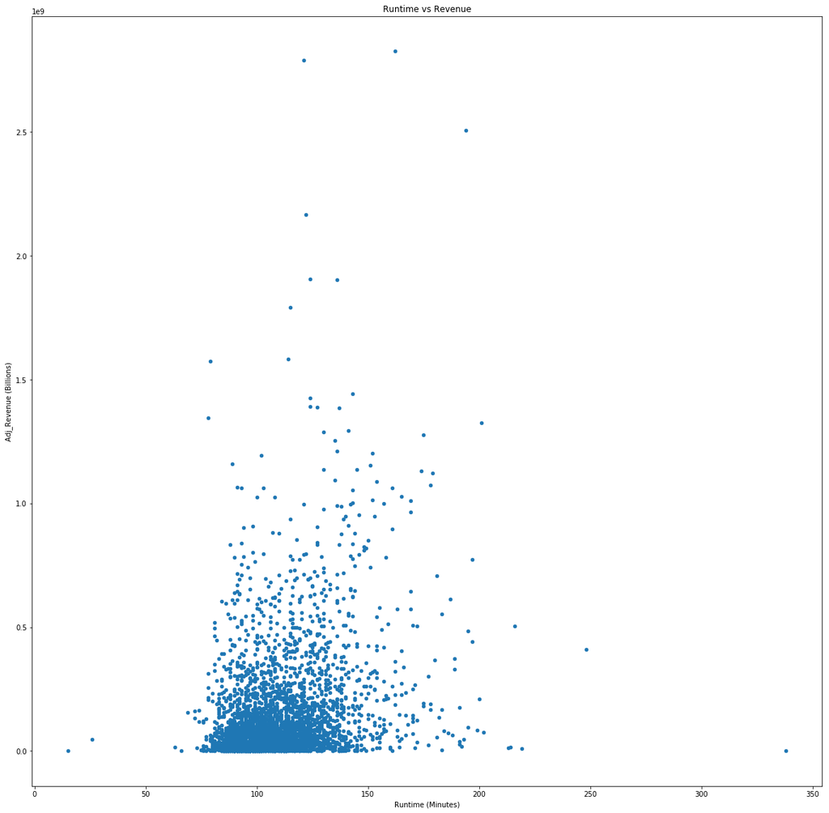

```python
# plot scatterplot of runtime vs revenue
df.plot(x='runtime', y='revenue_adj',figsize=(20,20),kind='scatter')
plt.xlabel('Runtime (Minutes)')
plt.ylabel('Adj_Revenue (Billions)')
plt.title('Runtime vs Revenue')
plt.legend()
plt.show()
```

> Again, no correlation between runtime and revenue but there is a zone, between 80-150 mins is where most of the high revenue movie are clocked.

##### Top 10 Movies

```python
# display top 10 movies by revenue
df.sort_values('revenue_adj', ascending=False).head(10)
```

|  | budget | revenue | original_title | cast | director | runtime | genres | production_companies | budget_adj | revenue_adj | year | month | day | budget_level | revenue_level |
| --- | --- | --- | --- | --- | --- | --- | --- | --- | --- | --- | --- | --- | --- | --- | --- |
| 1386 | 237000000.0 | 2.781506e+09 | Avatar | Sam Worthington\|Zoe Saldana\|Sigourney Weaver\|S... | James Cameron | 162 | Action\|Adventure\|Fantasy\|Science Fiction | Ingenious Film Partners\|Twentieth Century Fox ... | 2.408869e+08 | 2.827124e+09 | 2009 | 12 | 10 | Very_High | Very_High |
| 1329 | 11000000.0 | 7.753980e+08 | Star Wars | Mark Hamill\|Harrison Ford\|Carrie Fisher\|Peter ... | George Lucas | 121 | Adventure\|Action\|Science Fiction | Lucasfilm\|Twentieth Century Fox Film Corporation | 3.957559e+07 | 2.789712e+09 | 1977 | 3 | 20 | High | Very_High |
| 5231 | 200000000.0 | 1.845034e+09 | Titanic | Kate Winslet\|Leonardo DiCaprio\|Frances Fisher\|... | James Cameron | 194 | Drama\|Romance\|Thriller | Paramount Pictures\|Twentieth Century Fox Film ... | 2.716921e+08 | 2.506406e+09 | 1997 | 11 | 18 | Very_High | Very_High |
| 10594 | 8000000.0 | 4.413061e+08 | The Exorcist | Linda Blair\|Max von Sydow\|Ellen Burstyn\|Jason ... | William Friedkin | 122 | Drama\|Horror\|Thriller | Warner Bros.\|Hoya Productions | 3.928928e+07 | 2.167325e+09 | 1973 | 12 | 26 | High | Very_High |
| 9806 | 7000000.0 | 4.706540e+08 | Jaws | Roy Scheider\|Robert Shaw\|Richard Dreyfuss\|Lorr... | Steven Spielberg | 124 | Horror\|Thriller\|Adventure | Universal Pictures\|Zanuck/Brown Productions | 2.836275e+07 | 1.907006e+09 | 1975 | 6 | 18 | Medium | Very_High |
| 3 | 200000000.0 | 2.068178e+09 | Star Wars: The Force Awakens | Harrison Ford\|Mark Hamill\|Carrie Fisher\|Adam D... | J.J. Abrams | 136 | Action\|Adventure\|Science Fiction\|Fantasy | Lucasfilm\|Truenorth Productions\|Bad Robot | 1.839999e+08 | 1.902723e+09 | 2015 | 12 | 15 | Very_High | Very_High |
| 8889 | 10500000.0 | 7.929106e+08 | E.T. the Extra-Terrestrial | Henry Thomas\|Drew Barrymore\|Robert MacNaughton... | Steven Spielberg | 115 | Science Fiction\|Adventure\|Family\|Fantasy | Universal Pictures\|Amblin Entertainment | 2.372625e+07 | 1.791694e+09 | 1982 | 4 | 3 | Medium | Very_High |
| 8094 | 22000000.0 | 1.106280e+09 | The Net | Sandra Bullock\|Jeremy Northam\|Dennis Miller\|We... | Irwin Winkler | 114 | Crime\|Drama\|Mystery\|Thriller\|Action | Columbia Pictures | 3.148127e+07 | 1.583050e+09 | 1995 | 7 | 28 | High | Very_High |
| 10110 | 4000000.0 | 2.158800e+08 | One Hundred and One Dalmatians | Rod Taylor\|J. Pat O'Malley\|Betty Lou Gerson\|Ma... | Clyde Geronimi\|Hamilton Luske\|Wolfgang Reitherman | 79 | Adventure\|Animation\|Comedy\|Family | Walt Disney Productions | 2.917944e+07 | 1.574815e+09 | 1961 | 1 | 25 | Medium | Very_High |
| 4361 | 220000000.0 | 1.519558e+09 | The Avengers | Robert Downey Jr.\|Chris Evans\|Mark Ruffalo\|Chr... | Joss Whedon | 143 | Science Fiction\|Action\|Adventure | Marvel Studios | 2.089437e+08 | 1.443191e+09 | 2012 | 4 | 25 | Very_High | Very_High |

> All of the top 10 movies are made up of all if not a combination of high revenue properties.

##### Bottom 10 Movies

```python
# display the bottom 10 movies by revenue
df.sort_values('revenue_adj', ascending=True).head(10)
```

|  | budget | revenue | original_title | cast | director | runtime | genres | production_companies | budget_adj | revenue_adj | year | month | day | budget_level | revenue_level |
| --- | --- | --- | --- | --- | --- | --- | --- | --- | --- | --- | --- | --- | --- | --- | --- |
| 5067 | 6000000.0 | 2.0 | Shattered Glass | Hayden Christensen\|Peter Sarsgaard\|Chloë Sevi... | Billy Ray | 94 | Drama\|History | Lions Gate Films\|Cruise/Wagner Productions\|Bau... | 7.112116e+06 | 2.370705 | 2003 | 11 | 14 | Low | Low |
| 8142 | 6000000.0 | 2.0 | Mallrats | Jason Lee\|Jeremy London\|Shannen Doherty\|Claire... | Kevin Smith | 94 | Romance\|Comedy | Gramercy Pictures\|Alphaville Films\|View Askew ... | 8.585801e+06 | 2.861934 | 1995 | 10 | 20 | Low | Low |
| 5162 | 10.0 | 5.0 | Kid's Story | Clayton Watson\|Keanu Reeves\|Carrie-Anne Moss\|K... | Shinichiro Watanabe | 15 | Science Fiction\|Animation | Studio 4°C | 1.185353e+01 | 5.926763 | 2003 | 6 | 2 | Low | Low |
| 8523 | 15000000.0 | 5.0 | Bordello of Blood | Dennis Miller\|Erika Eleniak\|Angie Everhart\|Joh... | Gilbert Adler | 87 | Horror\|Comedy | Tales From The Crypt Holdings\|Universal City S... | 2.085325e+07 | 6.951084 | 1996 | 8 | 16 | Medium | Low |
| 8226 | 6400000.0 | 6.0 | Never Talk to Strangers | Rebecca De Mornay\|Antonio Banderas\|Dennis Mill... | Peter Hall | 86 | Thriller\|Romance | TriStar Pictures | 9.158188e+06 | 8.585801 | 1995 | 10 | 20 | Low | Low |
| 10307 | 25000000.0 | 6.0 | The House of the Spirits | Meryl Streep\|Glenn Close\|Jeremy Irons\|Winona R... | Bille August | 140 | Romance\|Drama | Det Danske Filminstitut\|Spring Creek Productio... | 3.773675e+07 | 9.056820 | 1993 | 10 | 19 | High | Low |
| 5852 | 10.0 | 11.0 | Hross í oss | Ingvar Eggert Sigurðsson\|Charlotte Bøving\|St... | Benedikt Erlingsson | 85 | Drama\|Romance\|Comedy | Filmhuset Gruppen\|Leiknar Myndir | 9.360334e+00 | 10.296367 | 2013 | 8 | 30 | Low | Low |
| 7158 | 23000000.0 | 12.0 | Chasing Liberty | Mandy Moore\|Stark Sands\|Tony Jayawardena\|Jerem... | Andy Cadiff | 111 | Comedy\|Romance | Alcon Entertainment\|ETIC Films\|C.R.G. Internat... | 2.655224e+07 | 13.853345 | 2004 | 1 | 9 | Medium | Low |
| 8235 | 6.0 | 11.0 | Tales from the Hood | Clarence Williams III\|Corbin Bernsen\|David Ala... | Rusty Cundieff | 98 | Horror\|Thriller | Savoy Pictures | 8.585801e+00 | 15.740636 | 1995 | 5 | 24 | Low | Low |
| 2519 | 25.0 | 13.0 | Angela's Ashes | Emily Watson\|Robert Carlyle\|Joe Breen\|Michael ... | Alan Parker | 145 | Drama | Paramount Pictures\|Universal Pictures | 3.272632e+01 | 17.017687 | 1999 | 12 | 25 | Low | Low |

### What is the main insight of the top 10 box office successes?

```python
# select movies with profit
df_succ = df.query('budget_adj < revenue_adj')
```

```python
pd.options.mode.chained_assignment = None
# create a profit column and populate it
# select top 10
df_succ['profit'] = df_succ['revenue_adj'] - df_succ['budget_adj']
df_succ.sort_values('profit', ascending=False).head(10)
```

|  | budget | revenue | original_title | cast | director | runtime | genres | production_companies | budget_adj | revenue_adj | year | month | day | budget_level | revenue_level | profit |
| --- | --- | --- | --- | --- | --- | --- | --- | --- | --- | --- | --- | --- | --- | --- | --- | --- |
| 1329 | 11000000.0 | 7.753980e+08 | Star Wars | Mark Hamill\|Harrison Ford\|Carrie Fisher\|Peter ... | George Lucas | 121 | Adventure\|Action\|Science Fiction | Lucasfilm\|Twentieth Century Fox Film Corporation | 3.957559e+07 | 2.789712e+09 | 1977 | 3 | 20 | High | Very_High | 2.750137e+09 |
| 1386 | 237000000.0 | 2.781506e+09 | Avatar | Sam Worthington\|Zoe Saldana\|Sigourney Weaver\|S... | James Cameron | 162 | Action\|Adventure\|Fantasy\|Science Fiction | Ingenious Film Partners\|Twentieth Century Fox ... | 2.408869e+08 | 2.827124e+09 | 2009 | 12 | 10 | Very_High | Very_High | 2.586237e+09 |
| 5231 | 200000000.0 | 1.845034e+09 | Titanic | Kate Winslet\|Leonardo DiCaprio\|Frances Fisher\|... | James Cameron | 194 | Drama\|Romance\|Thriller | Paramount Pictures\|Twentieth Century Fox Film ... | 2.716921e+08 | 2.506406e+09 | 1997 | 11 | 18 | Very_High | Very_High | 2.234714e+09 |
| 10594 | 8000000.0 | 4.413061e+08 | The Exorcist | Linda Blair\|Max von Sydow\|Ellen Burstyn\|Jason ... | William Friedkin | 122 | Drama\|Horror\|Thriller | Warner Bros.\|Hoya Productions | 3.928928e+07 | 2.167325e+09 | 1973 | 12 | 26 | High | Very_High | 2.128036e+09 |
| 9806 | 7000000.0 | 4.706540e+08 | Jaws | Roy Scheider\|Robert Shaw\|Richard Dreyfuss\|Lorr... | Steven Spielberg | 124 | Horror\|Thriller\|Adventure | Universal Pictures\|Zanuck/Brown Productions | 2.836275e+07 | 1.907006e+09 | 1975 | 6 | 18 | Medium | Very_High | 1.878643e+09 |
| 8889 | 10500000.0 | 7.929106e+08 | E.T. the Extra-Terrestrial | Henry Thomas\|Drew Barrymore\|Robert MacNaughton... | Steven Spielberg | 115 | Science Fiction\|Adventure\|Family\|Fantasy | Universal Pictures\|Amblin Entertainment | 2.372625e+07 | 1.791694e+09 | 1982 | 4 | 3 | Medium | Very_High | 1.767968e+09 |
| 3 | 200000000.0 | 2.068178e+09 | Star Wars: The Force Awakens | Harrison Ford\|Mark Hamill\|Carrie Fisher\|Adam D... | J.J. Abrams | 136 | Action\|Adventure\|Science Fiction\|Fantasy | Lucasfilm\|Truenorth Productions\|Bad Robot | 1.839999e+08 | 1.902723e+09 | 2015 | 12 | 15 | Very_High | Very_High | 1.718723e+09 |
| 8094 | 22000000.0 | 1.106280e+09 | The Net | Sandra Bullock\|Jeremy Northam\|Dennis Miller\|We... | Irwin Winkler | 114 | Crime\|Drama\|Mystery\|Thriller\|Action | Columbia Pictures | 3.148127e+07 | 1.583050e+09 | 1995 | 7 | 28 | High | Very_High | 1.551568e+09 |
| 10110 | 4000000.0 | 2.158800e+08 | One Hundred and One Dalmatians | Rod Taylor\|J. Pat O'Malley\|Betty Lou Gerson\|Ma... | Clyde Geronimi\|Hamilton Luske\|Wolfgang Reitherman | 79 | Adventure\|Animation\|Comedy\|Family | Walt Disney Productions | 2.917944e+07 | 1.574815e+09 | 1961 | 1 | 25 | Medium | Very_High | 1.545635e+09 |
| 7309 | 18000000.0 | 5.384000e+08 | The Empire Strikes Back | Mark Hamill\|Harrison Ford\|Carrie Fisher\|Billy ... | Irvin Kershner | 124 | Adventure\|Action\|Science Fiction | Lucasfilm\|Twentieth Century Fox Film Corporation | 4.762866e+07 | 1.424626e+09 | 1980 | 1 | 1 | High | Very_High | 1.376998e+09 |

> Out of the top 10 most successful movies, 7 have had high to very_high budgets (30.3 to 425 Million). You need money to make money...

### What is the main insight of the top 10 biggest box office bombs? (Movies did not generate a profit)

```python
# select movies with losses
df_fail = df.query('budget_adj > revenue_adj')
```

```python
# create a loss column and populate it
# select top 10
pd.options.mode.chained_assignment = None
df_fail['loss'] = df_fail['budget_adj'] - df_fail['revenue_adj']
df_fail.sort_values('loss', ascending=False).head(10)
```

|  | budget | revenue | original_title | cast | director | runtime | genres | production_companies | budget_adj | revenue_adj | year | month | day | budget_level | revenue_level | loss |
| --- | --- | --- | --- | --- | --- | --- | --- | --- | --- | --- | --- | --- | --- | --- | --- | --- |
| 2244 | 425000000.0 | 11087569.0 | The Warrior's Way | Kate Bosworth\|Jang Dong-gun\|Geoffrey Rush\|Dann... | Sngmoo Lee | 100 | Adventure\|Fantasy\|Action\|Western\|Thriller | Boram Entertainment Inc. | 4.250000e+08 | 1.108757e+07 | 2010 | 12 | 2 | Very_High | Low | 4.139124e+08 |
| 5508 | 255000000.0 | 89289910.0 | The Lone Ranger | Johnny Depp\|Armie Hammer\|William Fichtner\|Hele... | Gore Verbinski | 149 | Action\|Adventure\|Western | Walt Disney Pictures\|Jerry Bruckheimer Films\|I... | 2.386885e+08 | 8.357833e+07 | 2013 | 7 | 3 | Very_High | High | 1.551102e+08 |
| 7031 | 145000000.0 | 25819961.0 | The Alamo | Dennis Quaid\|Billy Bob Thornton\|Jason Patric\|P... | John Lee Hancock | 137 | Western\|History\|War | Imagine Entertainment\|Touchstone Pictures | 1.673946e+08 | 2.980774e+07 | 2004 | 4 | 7 | Very_High | Medium | 1.375868e+08 |
| 2435 | 160000000.0 | 61698899.0 | The 13th Warrior | Antonio Banderas\|Vladimir Kulich\|Dennis StorhÃ... | John McTiernan | 102 | Adventure\|Fantasy\|Action | Touchstone Pictures | 2.094485e+08 | 8.076712e+07 | 1999 | 8 | 27 | Very_High | High | 1.286813e+08 |
| 4970 | 100000000.0 | 250.0 | Brother Bear | Joaquin Phoenix\|Jeremy Suarez\|Rick Moranis\|Joa... | Aaron Blaise\|Robert Walker | 85 | Animation\|Adventure\|Family\|Fantasy | Walt Disney Pictures\|Walt Disney Feature Anima... | 1.185353e+08 | 2.963382e+02 | 2003 | 10 | 20 | Very_High | Low | 1.185350e+08 |
| 8102 | 98000000.0 | 18517322.0 | Cutthroat Island | Geena Davis\|Matthew Modine\|Frank Langella\|Maur... | Renny Harlin | 119 | Action\|Adventure | Le Studio Canal+\|Laurence Mark Productions\|Met... | 1.402348e+08 | 2.649767e+07 | 1995 | 12 | 22 | Very_High | Medium | 1.137371e+08 |
| 4078 | 100000000.0 | 7103973.0 | The Adventures of Pluto Nash | Eddie Murphy\|Randy Quaid\|Rosario Dawson\|Joe Pa... | Ron Underwood | 95 | Action\|Comedy\|Science Fiction | Village Roadshow Pictures\|Castle Rock Entertai... | 1.212261e+08 | 8.611872e+06 | 2002 | 8 | 15 | Very_High | Low | 1.126143e+08 |
| 3484 | 150000000.0 | 38992758.0 | Mars Needs Moms | Seth Green\|Joan Cusack\|Dan Fogler\|Breckin Meye... | Simon Wells | 88 | Adventure\|Animation\|Family | Walt Disney Animation Studios | 1.454097e+08 | 3.779950e+07 | 2011 | 3 | 9 | Very_High | Medium | 1.076102e+08 |
| 7332 | 44000000.0 | 3484331.0 | Heaven's Gate | Kris Kristofferson\|Christopher Walken\|John Hur... | Michael Cimino | 219 | Action\|Drama\|History\|Western | United Artists | 1.164256e+08 | 9.219668e+06 | 1980 | 11 | 19 | Very_High | Low | 1.072059e+08 |
| 8765 | 90000000.0 | 14828081.0 | Supernova | James Spader\|Angela Bassett\|Robert Forster\|Lou... | Walter Hill\|Jack Sholder | 91 | Science Fiction | United Artists\|Metro-Goldwyn-Mayer (MGM)\|Hamme... | 1.139663e+08 | 1.877668e+07 | 2000 | 1 | 14 | Very_High | Low | 9.518961e+07 |

> This perfectly demonstrates that although most movies with high revenues have high budgets, high budgets don't guarantee high revenues and in fact increases the likely-hood of a BOMB.

## Conclusions

#### Summary Insights

> Highest budget allotted to a film was approx 425 million!

> Highest revenue from a film was approx and 2.781 billion!

> Movie release years range from 1960 to 2015, with most between 1995 and 2015.

##### The majority of movies have:

> a budget between 0-70 million.

> revenues between 0-250 million.

> recently released, between 1995-2015. during the holiday season.

> have runtime between 80-150 minutes.

> Movie production has increased over the years but seems to have reached a plateau over the last 5 years.

> The cumulative sum of movie budgets has increased over the years but seems to have reached a plateau over the last 5 years. Makes sense since movie production has also increased.

> The mean of movie budgets has fluctuated over time. Movies today seem to be cheaper to make compared to those in the 1960's. The mean budget for movies today seems to have settled at around 40 - 45 million dollars.

> > The sum of movie budget has increased because of the increase of movie production and not because movie are more expensive to make.

> The cumulative sum of movie revenue has increased over the years.

> Adjusted for inflation, movies raked in more money between the 1960's and 1980's vs today! Interesting...

> > The sum of movie revenues has increased because of the increase of movie production and not because movie are raking in more money.

### Questions Addressed

#### Which genre has lead in each category in the last 5 years?

> In 4 of the last 5 years Action movies have been the most expensive to produce. Adventure movies over took Action in 2015. Adventure movies has commanded most of the revenues in 4 of the last 5 years with 2014 being the year it fell behind but it quickly bounced back on 2015.

#### What kinds of properties are associated with movies that have high revenues(adj)?

##### Cast

> Harrison Ford leads with rake in revenue of 14 Billion Dollars! Tom Cruise and Tom Hanks follow with 11 Billion and 10.5 Billion respectfully.

##### Genres

> Action, Adventure, Drama, Comedy, and Thriller lead with 210, 200, 175, 160, 150 Billion Dollars respectfully.

##### Production Companies

> Warner Bros., Universal Pictures, Paramount Pictures, Twentieth Century, and Walt Disney lead with 67, 61, 54, 50, 37 Billion respectfully.

##### Directors

> Steven Spielberg leads with 15 Billion in revenues! James Cameron, Peter Jackson, and George Lucas follow with 7.2, 7.0, 6.2 Billion. Steven has more than double the runner up!

##### Revenues vs Budgets

> 62.67% of movies with Very_High budgets have Very_High revenues. 62.6% of movies with Very_revenue budget have Very_High budgets.

> Does not seem to be a correlation between revenue and budget, there might be a very small positive correlation if any.

> Again, no correlation between runtime and revenue but there is a zone, between 80-150 mins is where most of the high revenue movie are clocked.

##### Properties of top and bottom movies

> All of the top 10 movies are made up of all if not a combination of high revenue properties.

> > Every top movie had all or a combination of top cast members (Harrison Ford), genre (Action/Adventure), production company (Warner Bros./20th cent), director (Steven Spielberg), high budget.

#### What is the main insight of the top 10 box office successes?

> Out of the top 10 most successful movies, 7 have had high to very_high budgets (30.3 to 425 Million). You need money to make money...

#### What are the top 10 biggest box office bombs? (Movies did not generate a profit)

> Top 10 biggest box office bombs perfectly demonstrates that although most movies with high revenues have high budgets, high budgets don't guarantee high revenues and in fact increases the likely-hood of a BOMB.

> > Also, I did notice that the director is very important.

> > > The main difference I see between the two lists is directors.

#### Limitations

> There was a large amount of data integrity issues due to missing data/values and unknown column origin/explaination. Initially, the data sample was just over 10000 rows but after the cleaning it was reduced to 3800... That's less than half! This reduction in sample space may have caused me to make incorrect conclusions about the box office.

```python
from subprocess import call
call(['python', '-m', 'nbconvert', 'Investigate_a_Dataset.ipynb'])
```

```
0
```